# final_case_study

# ============================================================

# EXTRA ANALYSIS SECTION

# ============================================================

# Revenue heatmaps

# Product category correlation

# Parallel coordinates customer profiles

# Stacked area revenue

# Product affinity network

# Survival curve

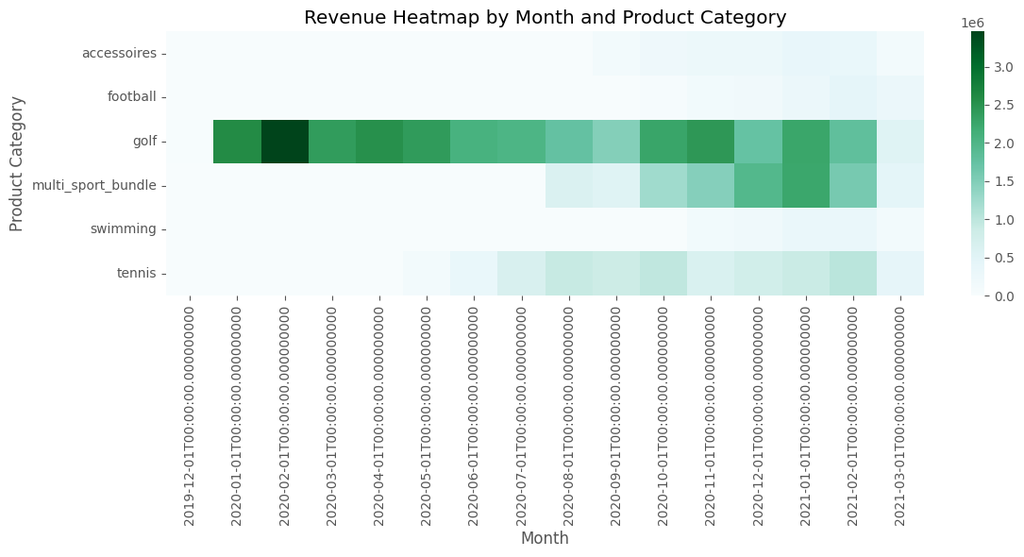

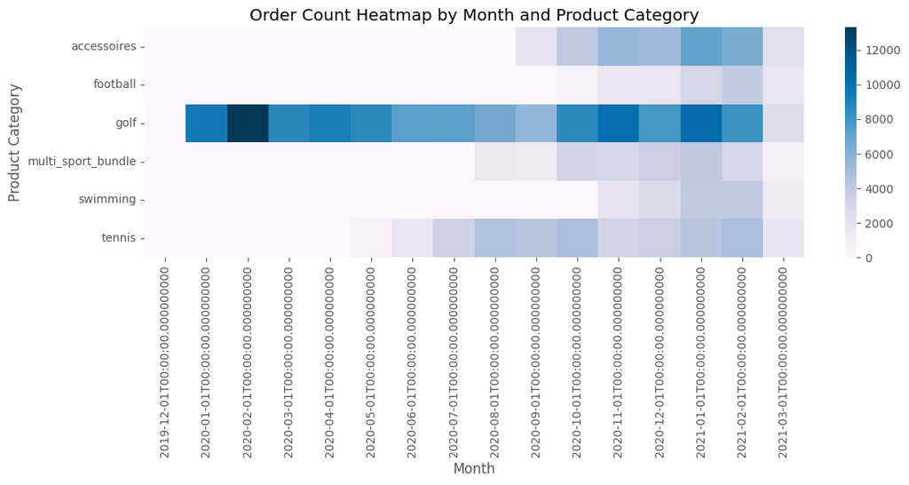

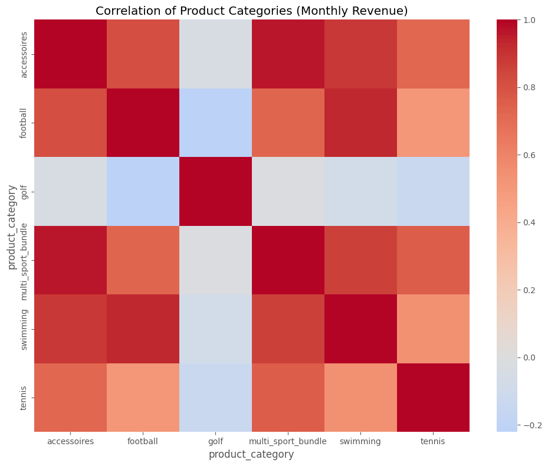

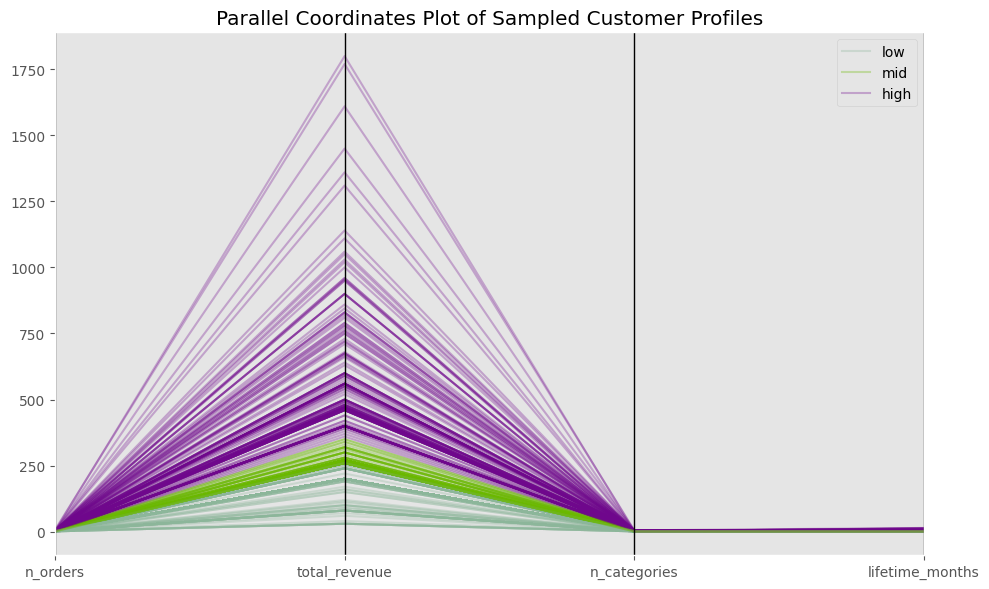

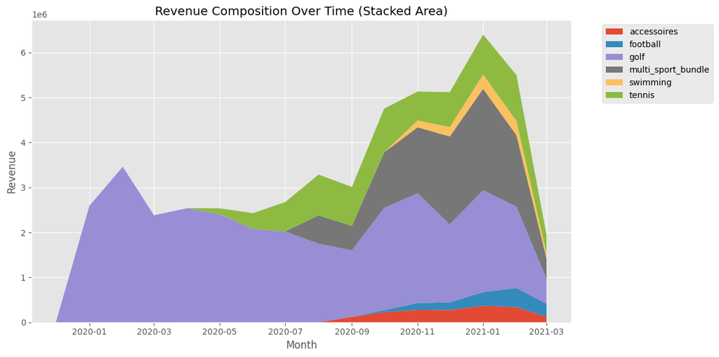

```
=== Top 20 category co-occurrences ===
                source              target  weight
0          accessoires                golf   10645
2                 golf              tennis   10322
5          accessoires              tennis    9324
6          accessoires  multi_sport_bundle    8530
12                golf            swimming    4552
7          accessoires            football    4539
1             football                golf    4431
10         accessoires            swimming    3187
4                 golf  multi_sport_bundle    2502
11            swimming              tennis    2409
8             football              tennis    2260
14            football            swimming    1875
13  multi_sport_bundle            swimming     207
3   multi_sport_bundle              tennis     203
9             football  multi_sport_bundle     187
```

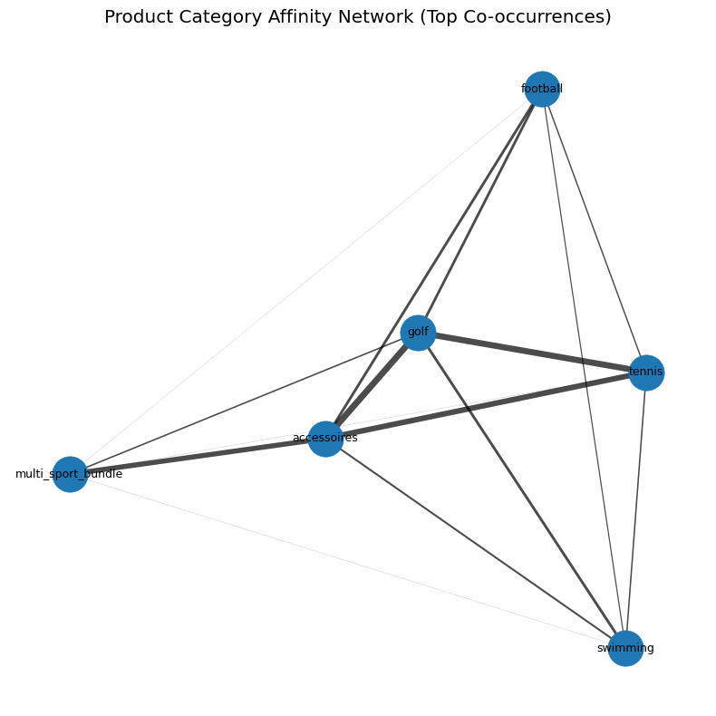

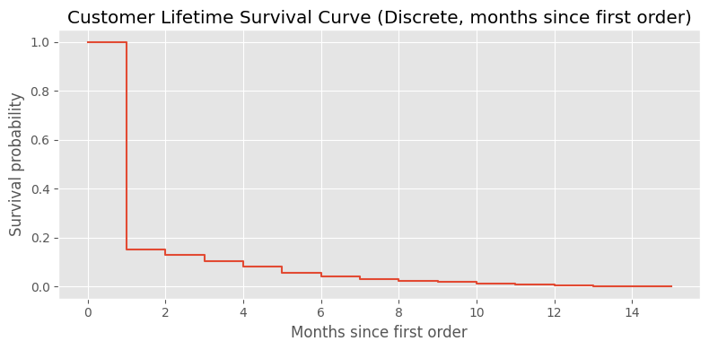

```python
# ============================================================
# 7. Revenue & Order Count Heatmaps by Month and Product Category
# ============================================================
rev_heatmap = rev_cat_month.pivot_table(
    index="product_category",
    columns="order_month",
    values="revenue",
    fill_value=0
)

plt.figure(figsize=(12, 6))
sns.heatmap(rev_heatmap, cmap="BuGn")
plt.title("Revenue Heatmap by Month and Product Category")
plt.xlabel("Month")
plt.ylabel("Product Category")
plt.tight_layout()
plt.show()

# Order count heatmap
order_counts_cat_month = (
    order_lines
    .groupby(["order_month", "product_category"])["order_number"]
    .nunique()
    .rename("n_orders")
    .reset_index()
)

order_count_heatmap = order_counts_cat_month.pivot_table(
    index="product_category",
    columns="order_month",
    values="n_orders",
    fill_value=0
)

plt.figure(figsize=(12, 6))
sns.heatmap(order_count_heatmap, cmap="PuBu")
plt.title("Order Count Heatmap by Month and Product Category")
plt.xlabel("Month")
plt.ylabel("Product Category")
plt.tight_layout()
plt.show()

# ============================================================
# 8. Correlation of Product Categories (monthly revenue)
# ============================================================
cat_month_matrix = rev_cat_month.pivot_table(
    index="order_month",
    columns="product_category",
    values="revenue",
    fill_value=0
)

cat_corr = cat_month_matrix.corr()

plt.figure(figsize=(10, 8))
sns.heatmap(cat_corr, cmap="coolwarm", center=0)
plt.title("Correlation of Product Categories (Monthly Revenue)")
plt.tight_layout()
plt.show()

# ============================================================
# 9. Parallel Coordinates: Sampled Customer Profiles
# ============================================================
cust_orders = (
    orders
    .groupby("customer_id")
    .agg(
        first_order=("order_month", "min"),
        last_order=("order_month", "max"),
        n_orders=("order_number", "nunique"),
        total_revenue=("order_revenue", "sum")
    )
)

cust_cats = (
    order_lines
    .groupby("customer_id")["product_category"]
    .nunique()
    .rename("n_categories")
)

cust_features = cust_orders.join(cust_cats, how="left")
cust_features["lifetime_months"] = get_month_diff(
    cust_features["last_order"], cust_features["first_order"]
) + 1

cust_features_num = cust_features[["n_orders", "total_revenue", "n_categories", "lifetime_months"]].copy()

# Segment customers by total revenue (low / mid / high)
cust_features_num["segment"] = pd.qcut(
    cust_features_num["total_revenue"],
    q=3,
    labels=["low", "mid", "high"]
)

# Sample customers for plotting
sampled = cust_features_num.sample(
    n=min(500, len(cust_features_num)),
    random_state=42
)

plt.figure(figsize=(10, 6))
parallel_coordinates(
    sampled.reset_index(),
    class_column="segment",
    cols=["n_orders", "total_revenue", "n_categories", "lifetime_months"],
    alpha=0.3
)
plt.title("Parallel Coordinates Plot of Sampled Customer Profiles")
plt.tight_layout()
plt.show()

# ============================================================
# 10. Revenue Composition Over Time (Stacked Area)
# ============================================================
rev_comp = rev_cat_month.pivot_table(
    index="order_month",
    columns="product_category",
    values="revenue",
    fill_value=0
).sort_index()

plt.figure(figsize=(12, 6))
plt.stackplot(
    rev_comp.index,
    rev_comp.values.T,
    labels=rev_comp.columns
)
plt.legend(bbox_to_anchor=(1.05, 1), loc="upper left")
plt.title("Revenue Composition Over Time (Stacked Area)")
plt.xlabel("Month")
plt.ylabel("Revenue")
plt.tight_layout()
plt.show()

# ============================================================
# 11. Product Category Affinity Network (strongest co-occurrence)
# ============================================================
order_cat_sets = (
    order_lines
    .dropna(subset=["product_category"])
    .groupby("order_number")["product_category"]
    .apply(lambda x: sorted(set(x)))
)

edge_weights = {}
for cats in order_cat_sets:
    if len(cats) < 2:
        continue
    for c1, c2 in combinations(cats, 2):
        edge = tuple(sorted((c1, c2)))
        edge_weights[edge] = edge_weights.get(edge, 0) + 1

edges_df = (
    pd.DataFrame(
        [
            {"source": e[0], "target": e[1], "weight": w}
            for e, w in edge_weights.items()
        ]
    )
    .sort_values("weight", ascending=False)
)

print("\n=== Top 20 category co-occurrences ===")
print(edges_df.head(20))

# Build network on strongest edges (top 30)
top_edges = edges_df.head(30)

G = nx.Graph()
for _, row in top_edges.iterrows():
    G.add_edge(row["source"], row["target"], weight=row["weight"])

plt.figure(figsize=(8, 8))
pos = nx.spring_layout(G, k=0.5, seed=42)
weights = [d["weight"] for (_, _, d) in G.edges(data=True)]
nx.draw_networkx_nodes(G, pos, node_size=800)
nx.draw_networkx_edges(
    G,
    pos,
    width=[w / max(weights) * 5 for w in weights],
    alpha=0.7
)
nx.draw_networkx_labels(G, pos, font_size=9)
plt.title("Product Category Affinity Network (Top Co-occurrences)")
plt.axis("off")
plt.tight_layout()
plt.show()

# ============================================================
# 12. Customer Lifetime Survival Curve (Discrete)
# ============================================================
lifetimes = cust_features["lifetime_months"].astype(int)

max_life = lifetimes.max()
survival = []
for t in range(0, max_life + 1):
    surv = (lifetimes > t).mean()
    survival.append({"month": t, "survival": surv})

survival_df = pd.DataFrame(survival)

plt.figure(figsize=(8, 4))
plt.step(survival_df["month"], survival_df["survival"], where="post")
plt.title("Customer Lifetime Survival Curve (Discrete, months since first order)")
plt.xlabel("Months since first order")
plt.ylabel("Survival probability")
plt.tight_layout()
plt.show()
```

## Revenue Heatmap

From this visualization, it is clear that the golf category consistently generates the highest revenue, as shown by its darker shading throughout the timeline. Multi-sport bundles also contribute significantly; however, their revenue is more seasonal, with noticeable peaks during the fourth quarter. Tennis shows steady but moderate revenue, while categories such as accessories, football, and swimming generate comparatively little revenue, reflected by their lighter shading.

## Order Count Heatmap

The data reveals that golf has both a high order count and high revenue, indicating strong customer demand. Multi-sport bundles receive fewer orders but still produce substantial revenue, suggesting that they are higher-priced items. Accessories, on the other hand, are ordered fairly often but contribute less to revenue due to their lower price point. Together, these insights show that bundles generate large revenue per order, while accessories rely more on volume but remain low-revenue items overall.

## Customer Lifetime Survival Curve

At month zero, all customers are active by definition, but the curve drops sharply after the first month, showing that many customers do not return to make a second purchase. After six months, only a very small proportion of customers remain active, and by twelve months, the survival probability approaches zero. This pattern highlights a significant retention issue: most customers are one-time buyers and do not engage in long-term purchasing behavior.

## References & Acknowledgments

I took help from these resources.

- OpenAI ChatGPT for brainstorming and methodological clarification.
- Stack Overflow – for troubleshooting and examples of Python/pandas usage.
- NetworkX documentation: https://networkx.org/documentation/stable/